# Analysis and Visualization of Twitter WeRateDogs Archive

#### by Luyuan Zhang, August 2018

import libraries

```python
import os
import pandas as pd
import numpy as np
import tweepy
import requests
from PIL import Image
from io import BytesIO
import json
import ast
from bs4 import BeautifulSoup as BS
import matplotlib.pyplot as plt
%matplotlib inline
```

load data

```python
df=pd.read_csv('twitter_archive_master.csv')
```

```python
df.head()
```

|  | tweet_id | timestamp | source | text | name | expanded_url | external_url | favorite_count | media_types | num_medias | retweet_count | rating | stage | jpg_url | img_num | image_prediction | confidence_level | is_dog |
| --- | --- | --- | --- | --- | --- | --- | --- | --- | --- | --- | --- | --- | --- | --- | --- | --- | --- | --- |
| 0 | 892420643555336193 | 2017-08-01 16:23:56 | Twitter for iPhone | This is Phineas. He's a mystical boy. Only eve... | Phineas | https://twitter.com/dog_rates/status/892420643... | None | 38509 | photo | 1 | 8487 | 13 | None | https://pbs.twimg.com/media/DGKD1-bXoAAIAUK.jpg | 1 | orange | 0.097049 | False |
| 1 | 892177421306343426 | 2017-08-01 00:17:27 | Twitter for iPhone | This is Tilly. She's just checking pup on you.... | Tilly | https://twitter.com/dog_rates/status/892177421... | None | 33011 | photo | 1 | 6243 | 13 | None | https://pbs.twimg.com/media/DGGmoV4XsAAUL6n.jpg | 1 | Chihuahua | 0.323581 | True |
| 2 | 891815181378084864 | 2017-07-31 00:18:03 | Twitter for iPhone | This is Archie. He is a rare Norwegian Pouncin... | Archie | https://twitter.com/dog_rates/status/891815181... | None | 24847 | photo | 1 | 4138 | 12 | None | https://pbs.twimg.com/media/DGBdLU1WsAANxJ9.jpg | 1 | Chihuahua | 0.716012 | True |
| 3 | 891689557279858688 | 2017-07-30 15:58:51 | Twitter for iPhone | This is Darla. She commenced a snooze mid meal... | Darla | https://twitter.com/dog_rates/status/891689557... | None | 41899 | photo | 1 | 8611 | 13 | None | https://pbs.twimg.com/media/DF_q7IAWsAEuuN8.jpg | 1 | paper_towel | 0.170278 | False |
| 4 | 891327558926688256 | 2017-07-29 16:00:24 | Twitter for iPhone | This is Franklin. He would like you to stop ca... | Franklin | https://twitter.com/dog_rates/status/891327558... | None | 40028 | photo | 2 | 9348 | 12 | None | https://pbs.twimg.com/media/DF6hr6BUMAAzZgT.jpg | 2 | basset | 0.555712 | True |

**Questions of interest:**  
These are my features of interest and the areas that I like to investigate in.

1. what's the percentage of images that are predicted to be dog?
2. does it affect the rating when there is not a dog in the image?
3. what are the most common dog breed?
4. what is the distribution of dog stage?
5. how does dog stage affect rating?
6. what's the distribution of media types?
7. are higher rated tweets retweeted more time?
8. are higher rated tweets liked more?  
   Answers to these questions are summarized in **summary of analysis**

### 1. what's the percentage of images that are predicted to be dog?

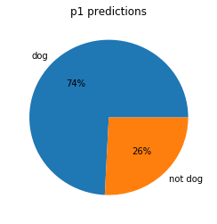

```python
plt.rcParams['figure.figsize'] = [4,4]
#percentage=list(df['is_dog'].value_counts()/df.shape[0]))
plt.pie(df['is_dog'].value_counts(),
        labels=['dog', 'not dog'],
       autopct='%.0f%%')
plt.title('p1 predictions');
```

**74% the images are predicted to be dog, and 26% are predicted not to be dog.**

back to top

### 2. does it affect the rating when there is not a dog in the image?

```python
dog=df.query('is_dog==True')
not_dog=df.query('is_dog==False')
```

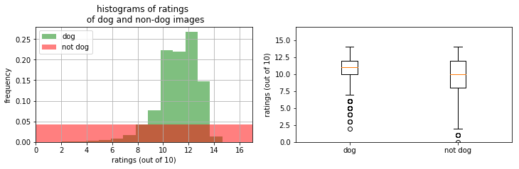

```python
plt.rcParams['figure.figsize'] = [12, 3]
plt.subplot(121)
dog_ratings=dog['rating'].unique()
nondog_ratings=dog['rating'].unique()
dog['rating'].hist(color='green',alpha=0.5,
                   bins=dog_ratings.max(),
                   density=True, label='dog')
not_dog['rating'].hist(color='red',alpha=0.5,
                   bins=nondog_ratings.max(),
                   density=True, label='not dog')
plt.legend()
plt.title('histograms of ratings \n of dog and non-dog images')
plt.xlim(0,17)
plt.xlabel('ratings (out of 10)')
plt.ylabel('frequency')

plt.subplot(122)
plt.boxplot([dog['rating'], not_dog['rating']], labels=['dog', 'not dog'])
#plt.boxplot(nondog_ratings, color='red')
plt.ylabel('ratings (out of 10)')
plt.ylim(0,17);
```

Based on the above plots, it looks to me that **images that are not dog received lower ratings**.

back to top

### 3. what are the top 10 most common dog breeds?

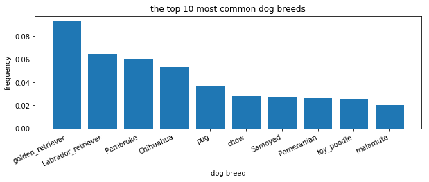

```python
plt.rcParams['figure.figsize'] = [10,3]
labels=dog['image_prediction'].value_counts()[:10].index
num_dog=dog.shape[0]
heights=dog['image_prediction'].value_counts()[:10]/num_dog
plt.bar(x=labels, height=heights)
plt.xticks(rotation=25, ha='right')
plt.ylabel('frequency')
plt.xlabel('dog breed')
plt.title('the top 10 most common dog breeds');
```

```python
dog['image_prediction'].value_counts()[:10]/num_dog*100
```

```
golden_retriever      9.308693
Labrador_retriever    6.433949
Pembroke              6.023272
Chihuahua             5.338809
pug                   3.696099
chow                  2.806297
Samoyed               2.737851
Pomeranian            2.600958
toy_poodle            2.532512
malamute              1.984942
Name: image_prediction, dtype: float64
```

**The top 10 most common dog breeds in the tweets are:** golden_retriever (9.3%), Labrador_retriever (6.4%), Pembroke (6.0%), Chihuahua (5.3%), pug (3.7%), chow (2.8%), Samoyed (2.7%), Pomeranian (2.6%), toy_poodle (2.5%), malamute (2.0%)

back to top

### 4. what is the distribution of dog stage like?

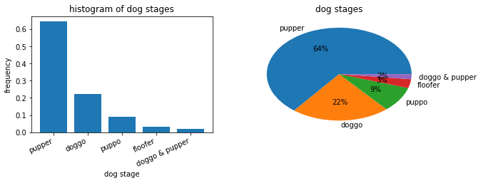

```python
# plot a histogram of dog stage that is not "None"
plt.subplot(121)
plt.rcParams['figure.figsize'] = [15,3]
staged_dog=dog[dog['stage']!='None']
total_num=staged_dog.shape[0]
labels=staged_dog['stage'].value_counts().index
heights=staged_dog['stage'].value_counts()
plt.bar(x=labels, height=heights/total_num)
plt.xticks(rotation=25, ha='right')
plt.ylabel('frequency')
plt.xlabel('dog stage')
plt.title('histogram of dog stages')

plt.subplot(122)
plt.pie(heights,
        labels=labels,
       autopct='%.0f%%')
plt.title('dog stages');
```

**Majority of dogs that has stage information are puppers (64%), followed by doggo (22%), and puppo (9%)**.

back to top

### 5. how does dog stage affect rating?

```python
staged_dog['stage'].value_counts()
```

```
pupper            146
doggo              50
puppo              20
floofer             7
doggo & pupper      4
Name: stage, dtype: int64
```

There are only 7 floofer and 4 doggo&pupper, so I will only consider pupper, doggo and puppo.

```python
doggo=staged_dog.query('stage=="doggo"')['rating']
puppo=staged_dog.query('stage=="puppo"')['rating']
pupper=staged_dog.query('stage=="pupper"')['rating']
```

```
''
```

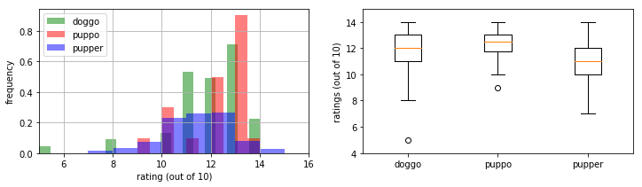

```python
plt.subplot(121)
plt.rcParams['figure.figsize'] = [10,3]
doggo.hist(density=True, color='green', alpha=0.5, bins=20,  label='doggo')
puppo.hist(density=True, color='red', alpha=0.5, bins=10, label='puppo')
pupper.hist(density=True, color='blue', bins=20, alpha=0.5, label='pupper')
plt.xlim(5,16)
plt.legend()
plt.xlabel('rating (out of 10)')
plt.ylabel('frequency')


plt.subplot(122)
plt.boxplot([doggo,puppo,pupper], labels=['doggo','puppo','pupper'])
plt.ylim(4,15)
plt.ylabel('ratings (out of 10)')
;
```

**Dog stage don't seem to affect rating**.

back to top

### 6. what's the distribution of media types?

```python
df['media_types'].value_counts()
```

```
photo           1894
video             72
animated_gif       3
Name: media_types, dtype: int64
```

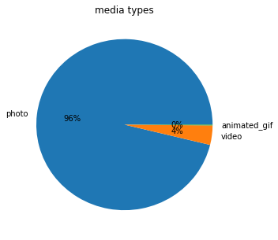

```python
plt.rcParams['figure.figsize']=[5,5]
values=df['media_types'].value_counts()
labels=(df['media_types'].value_counts()).index
plt.pie(values,
        labels=labels,
       autopct='%.0f%%')
plt.title('media types');
```

**96% of the media are photos, 4% are videos, and less than 1% are animated_gif**

back to top

### 7. are higher rated tweets retweeted more time?

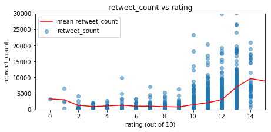

```python
#plot a scater plot of retweet_count vs rating
plt.rcParams['figure.figsize']=[7,3]
plt.scatter(x=df['rating'], y=df['retweet_count'], alpha=0.5, label='retweet_count')
plt.plot(((df.groupby('rating')['retweet_count']).agg('mean')), color='red', label='mean retweet_count')
plt.xlim(-1,15)
plt.legend()
plt.ylim(0,30000)
plt.xticks()
plt.xlabel('rating (out of 10)')
plt.ylabel('retweet_count')
plt.title('retweet_count vs rating');
```

**higher rated tweets are retweeted more times**

back to top

### 8. are higher rated tweets more liked?

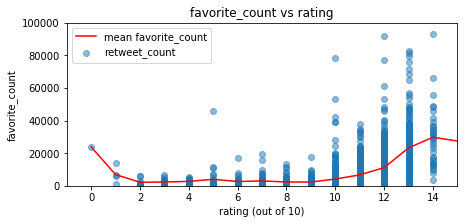

```python
#plot a scater plot of retweet_count vs rating
plt.rcParams['figure.figsize']=[7,3]
plt.scatter(x=df['rating'], y=df['favorite_count'], alpha=0.5, label='retweet_count')
plt.plot(((df.groupby('rating')['favorite_count']).agg('mean')), color='red', label='mean favorite_count')
plt.xlim(-1,15)
plt.legend()
plt.ylim(0,100000)
plt.xticks()
plt.xlabel('rating (out of 10)')
plt.ylabel('favorite_count')
plt.title('favorite_count vs rating');
```

**higher rated tweets are more liked.**

back to top of "Data analysis and visualization" back to top of the report

### Summary of analysis

- The top 10 most common dog breeds in the tweets are: golden_retriever (9.3%), Labrador_retriever (6.4%), Pembroke (6.0%), Chihuahua (5.3%), pug (3.7%), chow (2.8%), Samoyed (2.7%), Pomeranian (2.6%), toy_poodle (2.5%), malamute (2.0%)
- images that are not dog received lower ratings.
- 74% the images are predicted to be dog, and 26% are predicted not to be dog.
- Majority of dogs that has stage information are puppers (64%), followed by doggo (22%), and puppo (9%).
- Dog stage don't seem to affect rating.
- 96% of the media are photos, 4% are videos, and less than 1% are animated_gif
- higher rated tweets are retweeted more times
- higher rated tweets are like more